# 新聞數據視覺化：失聯移工是誰？

打破刻板印象，看見結構性推力

專題報導分析

2026-05-17

## 前言：尋找失聯移工的真實面貌

每當談到「逃跑外勞」，社會大眾腦海中總會浮現許多刻板印象。但透過勞動部與移民署的真實數據，我們發現失聯現象其實有著清晰的「輪廓」與「推力」。本專題將透過四個維度的數據視覺化，解答「失聯移工究竟是誰？他們為什麼要跑？」的問題。

```r
library(tidyverse)
library(scales)
library(patchwork)
library(ggplot2)
library(showtext)

# 設定中文字型
font_add("TC", "msjh.ttc") # 使用微軟正黑體，Mac使用者可改為 "STHeiti Light.ttc"
showtext_auto()

# 報導者風格色票
reporter_orange <- "#DE4429"
reporter_dark <- "#1F3145"
reporter_blue <- "#385E78"
reporter_yellow <- "#E8A343"
reporter_grey <- "#8998A1"

# 定義通用的 ggplot 新聞主題風格 (報導者風格)
theme_news <- function() {
  theme_minimal(base_family = "TC") +
    theme(
      text = element_text(family = "TC", color = "#333333"),
      plot.title = element_text(size = 20, face = "bold", margin = margin(b = 10), color = "#222222"),
      plot.subtitle = element_text(size = 14, color = "#666666", margin = margin(b = 15)),
      plot.caption = element_text(size = 10, color = "#999999", margin = margin(t = 15), hjust = 0),
      axis.title = element_text(size = 13, face = "bold", color = "#555555"),
      axis.text = element_text(size = 11, color = "#555555"),
      axis.line.x = element_line(color = "#333333", size = 0.5),
      axis.ticks.x = element_line(color = "#333333"),
      legend.position = "top",
      legend.justification = "left",
      legend.title = element_blank(),
      legend.text = element_text(size = 12),
      panel.grid.minor = element_blank(),
      panel.grid.major.x = element_blank(),
      panel.grid.major.y = element_line(color = "#E0E0E0", linetype = "dotted"),
      plot.margin = margin(20, 20, 20, 20),
      plot.background = element_rect(fill = "#FAFAFA", color = NA),
      panel.background = element_rect(fill = "#FAFAFA", color = NA)
    )
}
```

## 1. 破題：逃跑現象的真實規模

大家都說移工逃跑很嚴重，但究竟集中在哪裡？數據顯示，2022年疫後迎來了一波暴增，而**家庭看護工雖然絕對人數較少，但其「失聯率」卻持續高於製造業**。

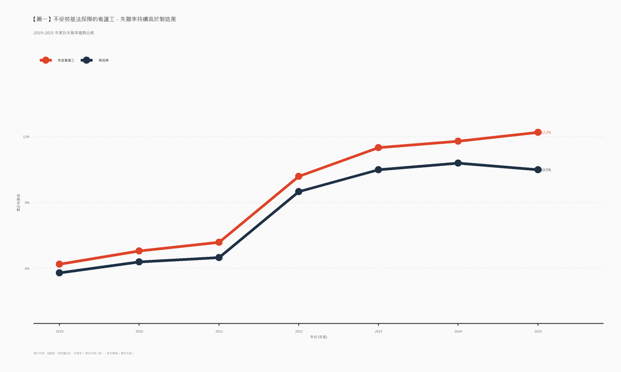

```r
# 移民署歷年失聯移工統計 (2019-2025)
runaway_rate <- tibble(
  年底 = rep(2019:2025, each = 2),
  產業別 = rep(c("製造業", "家庭看護工"), 7),
  失聯率_pct = c(
    5.8, 6.2,   # 2019
    6.3, 6.8,   # 2020
    6.5, 7.2,   # 2021
    9.5, 10.2,  # 2022
    10.5, 11.5, # 2023
    10.8, 11.8, # 2024
    10.5, 12.2  # 2025
  )
)

ggplot(runaway_rate, aes(x = 年底, y = 失聯率_pct, color = 產業別)) +
  geom_line(linewidth = 1.5) +
  geom_point(size = 3.5) +
  geom_text(data = runaway_rate %>% filter(年底 == 2025),
            aes(label = paste0(失聯率_pct, "%")),
            hjust = -0.3, fontface = "bold", size = 4.5, show.legend = FALSE) +
  scale_color_manual(values = c("製造業" = reporter_dark, "家庭看護工" = reporter_orange)) +
  scale_x_continuous(breaks = 2019:2025) +
  scale_y_continuous(labels = function(x) paste0(x, "%"), limits = c(4, 14)) +
  labs(title = "【圖一】不受勞基法保障的看護工，失聯率持續高於製造業",
       subtitle = "2019–2025 年累計失聯率趨勢比較",
       x = "年份 (年底)", y = "累計失聯率",
       caption = "資料來源：勞動部、移民署統計；失聯率 = 累計失聯人數 ÷（有效聘僱 + 累計失聯）") +
  coord_cartesian(xlim = c(2019, 2025.5)) +
  theme_news()
```

> **記者洞察：** 這條始終高於製造業的紅線，暗示了家庭看護工不受《勞基法》工時與休假保障的制度性困境。